# Análisis proyecto Control Box

## EDA Covid 19

Este notebook busca explorar el set de datos de pacientes que se hicieron la prueba de covid-19.

|  | MUNICIPIO | lat | lon | RESULTADO PCR_x | RESULTADO PCR_y |
| --- | --- | --- | --- | --- | --- |
| 0 | Lorica | 9.239458 | -75.813979 | 9 | 162 |
| 1 | Montelibano | 7.980053 | -75.416720 | 5 | 116 |
| 2 | Planeta Rica | 8.407674 | -75.584046 | 1 | 167 |
| 3 | Sahagun | 8.947296 | -75.443497 | 23 | 237 |
| 4 | Tierralta | 8.171734 | -76.059376 | 5 | 140 |

[interactive chart not shown]

Veamos que Columnas tienen en común y quedaron luego del inner Join.

```
<class 'pandas.core.frame.DataFrame'>
Int64Index: 822 entries, 0 to 35
Data columns (total 77 columns):
 #   Column                                                 Non-Null Count  Dtype
---  ------                                                 --------------  -----
 0   PRIMER NOMBRE                                          822 non-null    object
 1   SEGUNDO NOMBRE                                         613 non-null    object
 2   PRIMER APELLIDO                                        822 non-null    object
 3   SEGUNDO APELLIDO                                       775 non-null    object
 4   MUNICIPIO                                              822 non-null    object
 5   AREA DEL MUNICIPIO                                     794 non-null    float64
 6   DIRECCIÓN                                              822 non-null    object
 7   TELEFONO                                               822 non-null    object
 8   EDAD                                                   822 non-null    object
 9   SEXO                                                   822 non-null    int64
 10  AFILIACION  AL SGSSS                                   822 non-null    int64
 11  LUGAR DE RESIDENCIA                                    822 non-null    int64
 12  ESCOLARIDAD                                            822 non-null    int64
 13  TOMA MEDICAMENTOS                                      822 non-null    int64
 14  FIEBRE Ó ESCALOFRIOS                                   822 non-null    int64
 15  TOS                                                    822 non-null    int64
 16  DIFICULTAD PARA RESPIRAR                               822 non-null    int64
 17  FATIGA                                                 822 non-null    int64
 18  DOLORES MUSCULARES Y CORPORALES                        822 non-null    int64
 19  DOLOR DE CABEZA                                        822 non-null    int64
 20  PERDIDAD DEL OLFATO O DEL GUSTO                        822 non-null    int64
 21  DOLOR DE GARGANTA                                      822 non-null    int64
 22  CONGESTION DE LA NARIZ                                 822 non-null    int64
 23  NÁUSEAS O VÓMITOS                                      822 non-null    int64
 24  DIARREA                                                822 non-null    int64
 25  LA PERSONA CON COVID ESTUVO AISLADA DE LOS DEMAS?      822 non-null    int64
 26  ALGUIEN COMPARTE HABITACION                            822 non-null    int64
 27  USAN MEDIDAS DE PROTECCION DENTRO DE LA CASA           822 non-null    int64
 28  USAN MASCARILLAS O CARETAS DENTRO DE LA VIVIENDA       822 non-null    int64
 29  DURANTE LA PANDEMIA ME HE QUEDADO EN CASA              822 non-null    int64
 30  CUANDO LLEGA DE LA CALLE SE QUITA Y LAVA LA ROPA       822 non-null    int64
 31  SE QUITA LOS ZAPATOS O LOS DESINFECTA                  822 non-null    int64
 32  UTILIZA TRANSPORTE PUBLICO                             822 non-null    object
 33  PARA MOVILIZARSE UTILIZA ALGUN ELEMENTO DE PROTECCIÓN  822 non-null    int64
 34  DE LOS ELEMENTOS DE PROTECCIÓN                         822 non-null    int64
```

[output cut: 96 more lines]

```
1    331
3     42
X      2
Name: CASA DE FAMILIARES, dtype: int64

NEGATIVO             776
POSITIVO              43
NO LLEGO MUESTRA       3
Name: RESULTADO PCR, dtype: int64

NEGATIVO            463
POSITIVO            345
Pendiente            11
NO LLEGO MUESTRA      3
Name: RESULTADO SEROLOGIA, dtype: int64
```

|  | AREA DEL MUNICIPIO | SEXO | AFILIACION AL SGSSS | LUGAR DE RESIDENCIA | ESCOLARIDAD | TOMA MEDICAMENTOS | FIEBRE Ó ESCALOFRIOS | TOS | DIFICULTAD PARA RESPIRAR | FATIGA | DOLORES MUSCULARES Y CORPORALES | DOLOR DE CABEZA | PERDIDAD DEL OLFATO O DEL GUSTO | DOLOR DE GARGANTA | CONGESTION DE LA NARIZ | NÁUSEAS O VÓMITOS | DIARREA | LA PERSONA CON COVID ESTUVO AISLADA DE LOS DEMAS? | ALGUIEN COMPARTE HABITACION | USAN MEDIDAS DE PROTECCION DENTRO DE LA CASA | USAN MASCARILLAS O CARETAS DENTRO DE LA VIVIENDA | DURANTE LA PANDEMIA ME HE QUEDADO EN CASA | CUANDO LLEGA DE LA CALLE SE QUITA Y LAVA LA ROPA | SE QUITA LOS ZAPATOS O LOS DESINFECTA | PARA MOVILIZARSE UTILIZA ALGUN ELEMENTO DE PROTECCIÓN | DE LOS ELEMENTOS DE PROTECCIÓN | DESINFECTO TODOS LOS PAQUETES QUE LLEGAN | TIENDA | SUPERMERCADO | … |
| --- | --- | --- | --- | --- | --- | --- | --- | --- | --- | --- | --- | --- | --- | --- | --- | --- | --- | --- | --- | --- | --- | --- | --- | --- | --- | --- | --- | --- | --- | --- |
| count | 794.000000 | 822.000000 | 822.000000 | 822.000000 | 822.000000 | 822.000000 | 822.000000 | 822.000000 | 822.000000 | 822.000000 | 822.000000 | 822.000000 | 822.000000 | 822.000000 | 822.000000 | 822.000000 | 822.000000 | 822.000000 | 822.000000 | 822.000000 | 822.000000 | 822.000000 | 822.000000 | 822.000000 | 822.000000 | 822.000000 | 822.000000 | 822.000000 | 822.000000 | … |
| mean | 1.342569 | 1.497567 | 1.690998 | 1.407543 | 4.881995 | 1.796837 | 1.815085 | 1.860097 | 1.920925 | 1.940389 | 1.812652 | 1.779805 | 1.872263 | 1.856448 | 1.884428 | 1.944039 | 1.934307 | 3.367397 | 3.428224 | 3.330900 | 3.386861 | 2.500000 | 1.263990 | 1.552311 | 1.416058 | 1.324818 | 1.701946 | 1.658151 | 1.782238 | … |
| std | 0.510694 | 0.500298 | 0.778450 | 0.865127 | 2.125065 | 0.479890 | 0.430128 | 0.390058 | 0.323388 | 0.296301 | 0.429072 | 0.451206 | 0.378451 | 0.393400 | 0.366071 | 0.290796 | 0.316906 | 1.144306 | 1.009857 | 1.178365 | 1.120607 | 1.381759 | 0.757998 | 0.945050 | 0.874394 | 0.742214 | 0.984643 | 0.570211 | 0.520026 | … |
| min | 1.000000 | 1.000000 | 1.000000 | 1.000000 | 1.000000 | 1.000000 | 1.000000 | 1.000000 | 1.000000 | 1.000000 | 1.000000 | 1.000000 | 1.000000 | 1.000000 | 1.000000 | 1.000000 | 1.000000 | 1.000000 | 1.000000 | 1.000000 | 1.000000 | 1.000000 | 1.000000 | 1.000000 | 1.000000 | 1.000000 | 1.000000 | 1.000000 | 1.000000 | … |
| 25% | 1.000000 | 1.000000 | 1.000000 | 1.000000 | 3.000000 | 2.000000 | 2.000000 | 2.000000 | 2.000000 | 2.000000 | 2.000000 | 2.000000 | 2.000000 | 2.000000 | 2.000000 | 2.000000 | 2.000000 | 4.000000 | 3.000000 | 3.000000 | 4.000000 | 1.000000 | 1.000000 | 1.000000 | 1.000000 | 1.000000 | 1.000000 | 1.000000 | 1.000000 | … |
| 50% | 1.000000 | 1.000000 | 2.000000 | 1.000000 | 6.000000 | 2.000000 | 2.000000 | 2.000000 | 2.000000 | 2.000000 | 2.000000 | 2.000000 | 2.000000 | 2.000000 | 2.000000 | 2.000000 | 2.000000 | 4.000000 | 4.000000 | 4.000000 | 4.000000 | 2.000000 | 1.000000 | 1.000000 | 1.000000 | 1.000000 | 1.000000 | 2.000000 | 2.000000 | … |
| 75% | 2.000000 | 2.000000 | 2.000000 | 1.000000 | 7.000000 | 2.000000 | 2.000000 | 2.000000 | 2.000000 | 2.000000 | 2.000000 | 2.000000 | 2.000000 | 2.000000 | 2.000000 | 2.000000 | 2.000000 | 4.000000 | 4.000000 | 4.000000 | 4.000000 | 4.000000 | 1.000000 | 3.000000 | 1.000000 | 1.000000 | 2.000000 | 2.000000 | 2.000000 | … |
| max | 3.000000 | 2.000000 | 5.000000 | 5.000000 | 9.000000 | 3.000000 | 3.000000 | 3.000000 | 3.000000 | 3.000000 | 3.000000 | 3.000000 | 3.000000 | 3.000000 | 3.000000 | 3.000000 | 3.000000 | 4.000000 | 4.000000 | 4.000000 | 4.000000 | 5.000000 | 4.000000 | 4.000000 | 4.000000 | 4.000000 | 4.000000 | 3.000000 | 3.000000 | … |

Podemos notar que el inner join fue exitoso, y que solo quedamos con las columnas que tienen en común.

El set de datos es un poco desbalanceado entre los pacientes sintomáticos y los asintomáticos, siendo mayor el set de datos asintomático.

Para ver los datos faltantes, la librería Klib es de bastante ayuda.

```
Displaying only columns with missing values.
```

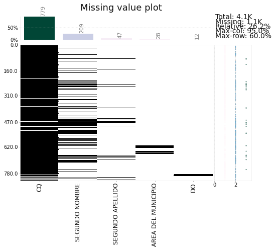

Los datos faltantes son datos de identificación de la persona, como su segundo nombre y su segundo apellido, el area del municipio deonde vive, y los resultados de las pruebas CQ y DO.

Para el modelado, podemos descartar la prueba CQ, ya que tiene una tasa de datos faltantes cercana o mayor al 60%. Descartar o no las columnas correspondientes a identificadores es opcional. Las columnas correspondientes al **Area del municipio** y al **DO** pueden ser de utilidad para las clasificaciones y extracción de patrones.

### Data Pre-processing

En esta sección nos será bastante util hacer un one hot encoding a las variables categóricas, así como mapear la sintomatología 2 (No presenta sintomas) a 0, para una interpretación más intuitiva y una posible mejora en el rendimiento del modelo. Otros tratamientos también serán implementados aquí.

Para que las variables categoricas pasen a ser numéricas, usaremos la siguiente función.

|  | AREA_DEL_MUNICIPIO | EDAD | SEXO | AFILIACION__AL_SGSSS | LUGAR_DE_RESIDENCIA | ESCOLARIDAD | TOMA_MEDICAMENTOS | FIEBRE_Ó_ESCALOFRIOS | TOS | DIFICULTAD_PARA_RESPIRAR | FATIGA | DOLORES_MUSCULARES_Y_CORPORALES | DOLOR_DE_CABEZA | PERDIDAD_DEL_OLFATO_O_DEL_GUSTO | DOLOR_DE_GARGANTA | CONGESTION_DE_LA_NARIZ_ | NÁUSEAS_O_VÓMITOS | DIARREA | LA_PERSONA_CON_COVID_ESTUVO_AISLADA_DE_LOS_DEMAS? | ALGUIEN_COMPARTE_HABITACION | USAN_MEDIDAS_DE_PROTECCION_DENTRO_DE_LA_CASA | USAN_MASCARILLAS_O_CARETAS_DENTRO_DE_LA_VIVIENDA | DURANTE_LA_PANDEMIA_ME_HE_QUEDADO_EN_CASA | CUANDO_LLEGA_DE_LA_CALLE_SE_QUITA_Y_LAVA_LA_ROPA | SE_QUITA_LOS_ZAPATOS_O_LOS_DESINFECTA | UTILIZA_TRANSPORTE_PUBLICO | PARA_MOVILIZARSE_UTILIZA_ALGUN_ELEMENTO_DE_PROTECCIÓN | DE_LOS_ELEMENTOS_DE_PROTECCIÓN | DESINFECTO_TODOS_LOS_PAQUETES_QUE_LLEGAN | … |
| --- | --- | --- | --- | --- | --- | --- | --- | --- | --- | --- | --- | --- | --- | --- | --- | --- | --- | --- | --- | --- | --- | --- | --- | --- | --- | --- | --- | --- | --- | --- |
| count | 796.000000 | 777.000000 | 796.000000 | 796.000000 | 796.000000 | 796.000000 | 769.000000 | 783.000000 | 784.000000 | 784.000000 | 784.000000 | 784.000000 | 784.000000 | 784.000000 | 784.000000 | 784.000000 | 784.000000 | 781.000000 | 796.000000 | 796.000000 | 796.000000 | 796.000000 | 796.000000 | 796.000000 | 796.000000 | 796.000000 | 796.000000 | 796.000000 | 796.000000 | … |
| mean | 1.359296 | 41.729730 | 1.503769 | 1.690955 | 1.417085 | 4.841709 | 0.247074 | 0.200511 | 0.155612 | 0.091837 | 0.072704 | 0.196429 | 0.233418 | 0.140306 | 0.158163 | 0.127551 | 0.073980 | 0.088348 | 3.383166 | 3.448492 | 3.354271 | 3.405779 | 2.483668 | 1.265075 | 1.550251 | 1.785176 | 1.412060 | 1.330402 | 1.708543 | … |
| std | 0.515473 | 16.611589 | 0.500300 | 0.786662 | 0.874177 | 2.128588 | 0.431591 | 0.400639 | 0.362719 | 0.288980 | 0.259816 | 0.397550 | 0.423276 | 0.347526 | 0.365127 | 0.333802 | 0.261905 | 0.283983 | 1.133889 | 0.994885 | 1.162353 | 1.107966 | 1.384000 | 0.766491 | 0.949671 | 0.612516 | 0.869355 | 0.750768 | 0.988221 | … |
| min | 1.000000 | 3.000000 | 1.000000 | 1.000000 | 1.000000 | 1.000000 | 0.000000 | 0.000000 | 0.000000 | 0.000000 | 0.000000 | 0.000000 | 0.000000 | 0.000000 | 0.000000 | 0.000000 | 0.000000 | 0.000000 | 1.000000 | 1.000000 | 1.000000 | 1.000000 | 1.000000 | 1.000000 | 1.000000 | 1.000000 | 1.000000 | 1.000000 | 1.000000 | … |
| 25% | 1.000000 | 29.000000 | 1.000000 | 1.000000 | 1.000000 | 3.000000 | 0.000000 | 0.000000 | 0.000000 | 0.000000 | 0.000000 | 0.000000 | 0.000000 | 0.000000 | 0.000000 | 0.000000 | 0.000000 | 0.000000 | 4.000000 | 4.000000 | 4.000000 | 4.000000 | 1.000000 | 1.000000 | 1.000000 | 1.000000 | 1.000000 | 1.000000 | 1.000000 | … |
| 50% | 1.000000 | 41.000000 | 2.000000 | 2.000000 | 1.000000 | 5.000000 | 0.000000 | 0.000000 | 0.000000 | 0.000000 | 0.000000 | 0.000000 | 0.000000 | 0.000000 | 0.000000 | 0.000000 | 0.000000 | 0.000000 | 4.000000 | 4.000000 | 4.000000 | 4.000000 | 2.000000 | 1.000000 | 1.000000 | 2.000000 | 1.000000 | 1.000000 | 1.000000 | … |
| 75% | 2.000000 | 54.000000 | 2.000000 | 2.000000 | 1.000000 | 6.000000 | 0.000000 | 0.000000 | 0.000000 | 0.000000 | 0.000000 | 0.000000 | 0.000000 | 0.000000 | 0.000000 | 0.000000 | 0.000000 | 0.000000 | 4.000000 | 4.000000 | 4.000000 | 4.000000 | 4.000000 | 1.000000 | 3.000000 | 2.000000 | 1.000000 | 1.000000 | 3.000000 | … |
| max | 3.000000 | 90.000000 | 2.000000 | 5.000000 | 5.000000 | 9.000000 | 1.000000 | 1.000000 | 1.000000 | 1.000000 | 1.000000 | 1.000000 | 1.000000 | 1.000000 | 1.000000 | 1.000000 | 1.000000 | 1.000000 | 4.000000 | 4.000000 | 4.000000 | 4.000000 | 5.000000 | 4.000000 | 4.000000 | 4.000000 | 4.000000 | 4.000000 | 4.000000 | … |

1. La dirección de residencia debemos mapearla a coordenadas.
2. El primer nombre, el apellido, el telefono los podemos descartar del set de datos.
3. Usaremos para el analisis exploratorio un modelo XGBoost, ya que este trata con los Nan, las categorías y los objetos sin problemas, es un modelo robusto, y nos puede indicar qué características son las más influyentes para la predicción.

Para el modelado es una buena practica quitar los espacios de los nombres de las caracteristicas.

### Feature Engineering

En esta sección se crean características que pueden ser útiles para el modelado, ente estas se encuentran relaciones (divisiones) entre síntomas, investigación en fuentes externas (PIB, IDH, Población de la ciudad), entre otras. Características como el ratio de infección cabeza/cuerpo o el PIB de su departamento dividido entre la población pueden ser de interés.

Podemos crear algunas características socioeconómicas.

1. Lorica.
2. Planeta Rica.
3. Tierralta.
4. Sahagún.
5. Montelíbano.

El PIB, la población, y el tamaño del municipio pueden dar cierta noción del desarrollo y las condiciones en éste. Variables como Densidad poblacional (Población/Area), o Ingresos por habitante (PIB/Población), también pueden ser de utilidad por la información socioeconómica que aportan.

Además podemos jugar con las variables que ya tenemos, personalizada por paciente, y crear unas adicionales.

### Gráficos

A partir del modelo, podemos ver que hay unas características que son más influyentes que otras a la hora de hacer la clasificación. La edad, el municipio, lugar frecuentado, sintomas de tos, disposición a vacunarse, etc.

A continuación analizaremos estas características con mayor detenimiento.

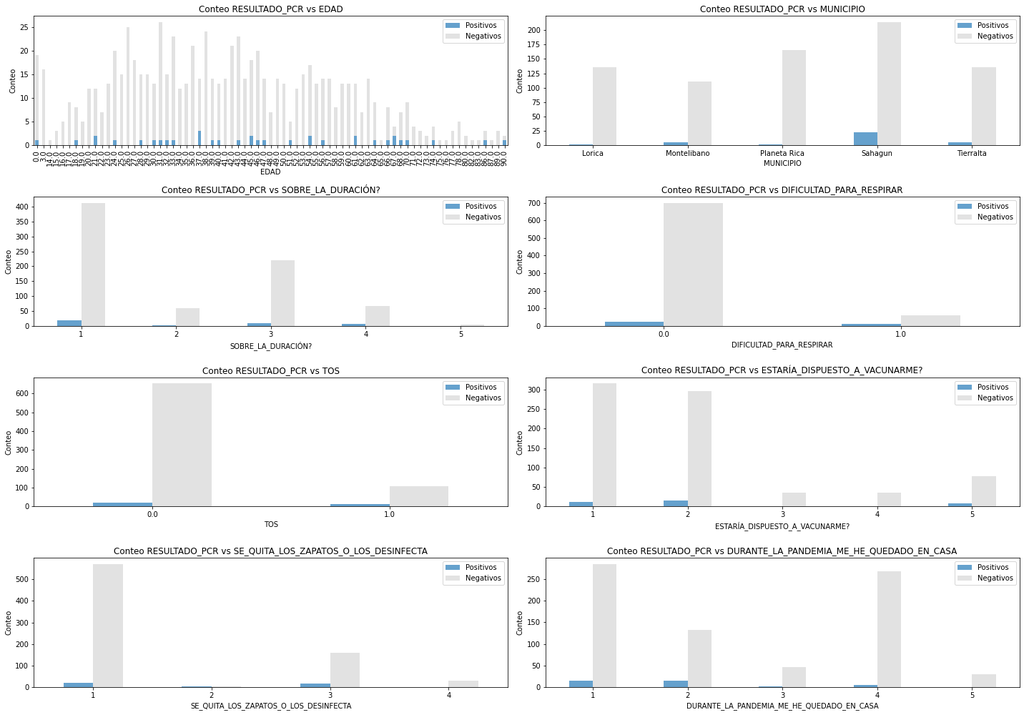

En promedio el grupo de personas Covid positivas, tienen una edad mayor. Esto puede significar que estas fueron las personas que necesitaron visitar un centro de salud, y no necesariamente el grupo poblacional con mayor tasa de contagios.

1. Durará hasta que salga la vacuna.
2. Esta por terminarse.
3. Vino para quedarse.
4. Sin Dato.
5. Ya se terminó.

No tenemos la definición del 1, 2 o el 3, pero el 0 es el trabajo. La convención daría a entender que un 3 significaría SIN DATO, pero un analisis es requerido, sino, sería más conveniente descartar esta variable.

Para la convención de sintomas.

1. No
2. Sí

1. Siempre.
2. Solo si es segura.
3. Solo si me obligan.
4. No me vacunaría.
5. Sin dato.
1. Siempre.
2. Solo algunas veces.
3. Nunca.
4. No reporta.

1. Siempre.
2. Solo algunas veces.
3. Salgo cada vez que puedo.
4. Salgo a trabajar.
5. Sin Dato.
1. Sí.
2. No.
3. Sin Dato

Al parecer, que una persona **no** presente dificultad para respirar, hace que sea mucho más probable un **resultado negativo** de PCR.

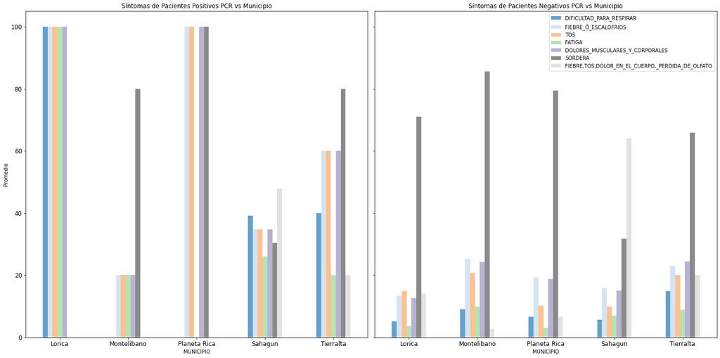

Una posible causa de la gravedad de los casos, o de la gran tasa de contagios en un municipio, podrían ser los síntomas que presentan los infectados del lugar, ya que hay unos síntomas que facilitan más la propagación que otros.

Podemos ver que dependiendo del municipio, los pacientes positivos tuvieron en promedio una sintomatología distinta. (El conteo de pacientes por municipio es diferente, así que un submuestreo podría estar implicito)

Las personas en Montelíbano, tanto positivas como negativas, mostraron síntomas de sordera, siendo la sintomatología en pacientes negativos, a veces hasta más abundante que en pacientes positivos.

A partir de ésta comparativa queda pendiente averiguar **qué** es lo que está causando la sordera en los casos negativos, ya que es algo recurrente.

En general la fiebre, la tos, o la dificultad para respirar fueron síntomas más comunes entre los casos positivos.

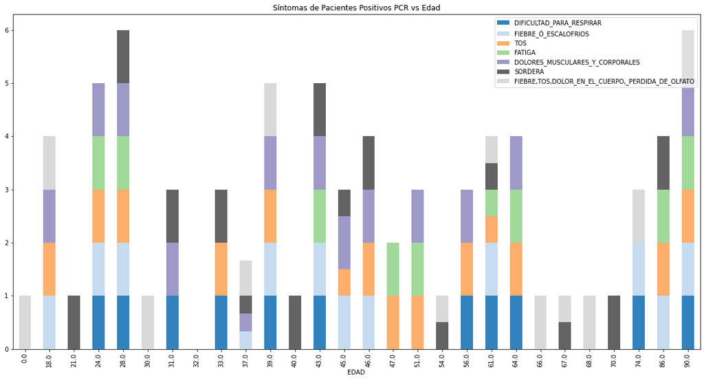

Sabemos que dependiendo de la Edad, la persona suele tener una respuesta inmune diferente, por lo que la sintomatología podría verse afectada. Veamos si hay una relación entre la edad de la persona y los sintomas que presenta.

Podemos ver que la sintomatología **aparentemente** se encuentra distribuida en todos los rangos de edad sin discriminación, por lo que la hipotesis se podría ser **Falsa**.

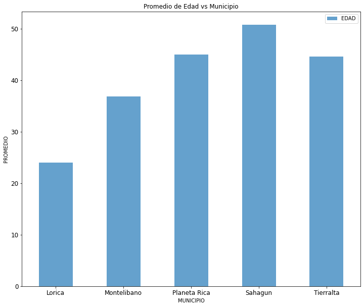

Con esto descartamos una relación de la edad con la sintomatología.

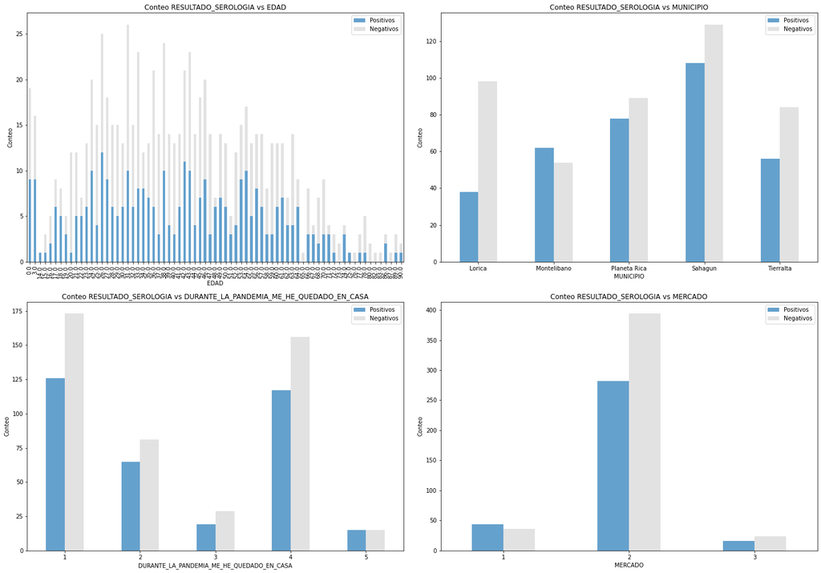

1. Siempre.
2. Solo algunas veces.
3. Salgo cada vez que puedo.
4. Salgo a trabajar.
5. Sin Dato.
1. Sí.
2. No.
3. Sin Dato.

Vimos que no es tan fácil clasificar los pacientes según los resultados de la prueba de Serología, pero este dato utilizado como una variable temporal nos puede dar indicios del desarrollo histórico de la pandemia en ciertos grupos (por municipio, estrato, etc).

Las personas que son positivas en la prueba de serología, es porque estuvieron contagiadas en el pasado, posteriormente podremos ver que muchos casos negativos en la PCR, presentaban sordera.

Analizando la sintomatología teniendo en cuenta el resultado serológico, podremos ver si la sordera fue una secuela del covid o no.

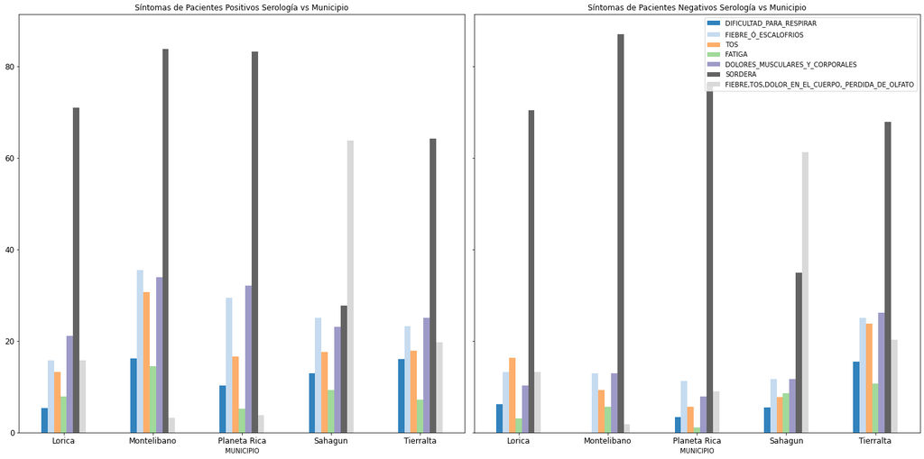

Como podemos observar, tanto los positivos como los negativos, presentaron sordera, por lo que comprobamos que ésta no está asociada a haber padecido covid en el pasado.

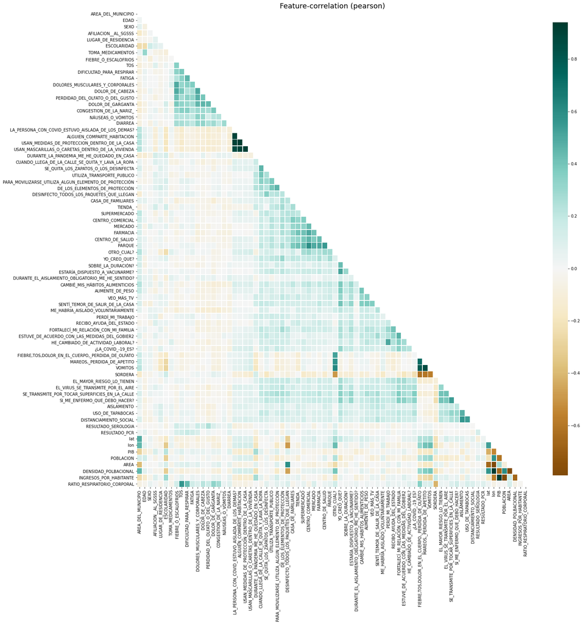

Podemos hacer un análisis de las correlaciones entre las variables. Antes de proceder al modelado exploratorio.

| OTRO_CUAL? | FIEBRE,TOS,DOLOR_EN_EL_CUERPO,_PERDIDA_DE_OLFATO | MAREOS,_PERDIDA_DE_APETITO | VOMITOS | SORDERA |
| --- | --- | --- | --- | --- |
| 1 | 2 | 2 | 2 | 2 |
| 2 | 604 | 604 | 604 | 604 |
| 3 | 186 | 186 | 186 | 186 |
| 4 | 1 | 1 | 1 | 1 |
| 5 | 2 | 2 | 2 | 2 |
| 6 | 1 | 1 | 1 | 1 |

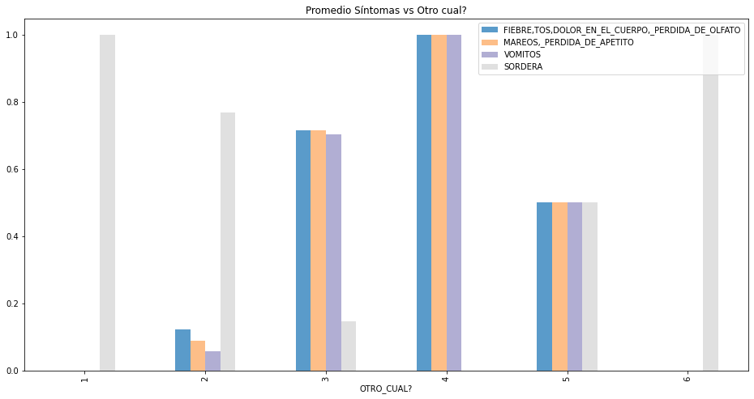

Hay una aparente relación entre los síntomas y la característica OTRO_CUAL?, ya que algunos valores de ésta presentan unicamente sordera, y otros, presentan casi todos los síntomas a la par. Ésto puede deberse a la baja cantidad de valores distintos a 2 y a 3 en la variable OTRO_CUAL?.

Ésta característica requiere un análisis más profundo, porque ha demostrado ser importante, y no tenemos mucha documentación sobre ella.

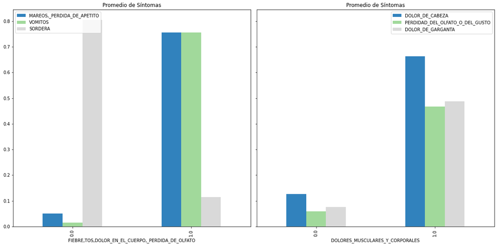

Al estar la variable *Fiebre, tos, dolor en el cuerpo*, fuertemente correlacionada positivavente con los *vómitos* y los *mareos*, las otras gráficas no son necesarias.

Podemos ver que en promedio, las personas que tenían éstos síntomas anteriormente mencionados, no padecían de sordera; las que **no** los tenían, **sí** padecieron sordera.

¿Esta correlación entre estos síntomas implicará una diferenciación del virus?

¿Qué tipos de covid hay?

¿Esta diferenciación puede ser debido a infecciones bacterianas? (analizar perdida de apetito)

¿Son estos síntomas predecibles?

## Modelado

### Pre-modelling

Esta etapa se centrará en eliminar las variables con alta correlación entre ellas, con el fin de mejorar el resultado del modelo y no tener información redundante.

```
Deleted:  INGRESOS_POR_HABITANTE
```

Set de datos de hábitos y set de datos de sintomas.

Antes de avanzar, hay que aclarar que en el set de datos existen 2 target.

**Resultados PCR**: La prueba PCR (Polimerase Chain Reaction) detecta si hay ARN del virus en la muestra que se toma, los resultados se obtienen entre 2 y 3 horas desde la prueba. Se toma una muestra del sistema respiratorio. Permite diferenciar entre 2 microrganismos similares, es muy *sensible*, detectando hasta 20 copias/mL, y en general se usa para detectar el virus en las *primeras fases* respiratorias.

**Resultados Serología**: La prueba de Serología, o prueba rápida, busca detectar los anticuerpos, generalmente se hace con muestras de sangre, aunque también las hay con muestras respiratorias, y tardan entre 10 y 15 minutos en arrojar resultados.

Hay que tener en cuenta que en algunos casos puede tardar *3 semanas* para desarrollar los anticuerpos, por lo que la prueba de serología no debe hacerse muy pronto, pero esta permite saber si se tuvo el virus hasta varios meses después.

En la primera fase del proyecto, nos centraremos en predecir los resultados de la prueba PCR, ya que de cierta forma un paciente hospitalario con un sindrome respiratorio agudo estaría más interesado en su estado actual, y la prueba de Serología al tomarse en las primeras etapas, o las etapas críticas, puede arrojar **Falsos negativos**.

```
Split Listo
 La proporción entre clases es: 21.714285714285715
Best Threshold=0.549986, G-Mean=0.879
```

```
La matriz de confusión:
 [[138  15]
 [  2   5]]
Un ejemplo de árbol de decisión.
```

```
AUC Score:  0.8081232492997199
```

```
(None, <matplotlib.axes._subplots.AxesSubplot at 0x7fddb4d84dd0>)
```

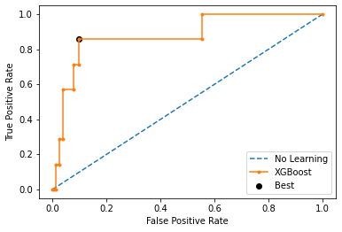

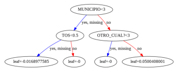

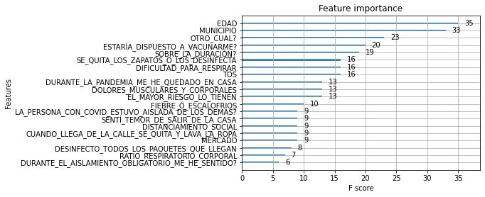

### Modelling (EDA) #2 Serología Mixto

El primer modelado fue analizando la prueba PCR del Covid. Este modelo tratará de predecir los resultados de la prueba de Serología.

Para esta prueba, no tiene mucho sentido analizar los sintomas de la persona ya que esta prueba también identifica pacientes que tuvieron la enfermedad. Por lo que descartar algunos datos podría ser de utilidad.

```
Split Listo
 La proporción entre clases es: 1.3296703296703296
Best Threshold=1.499931, G-Mean=0.000
```

```
La matriz de confusión:
 [[91  0]
 [69  0]]
Un ejemplo de árbol de decisión.
```

```
AUC Score:  0.5
Luego de 600 rondas, el modelo que busca predecir el resultado de la serología no encuentra ninguna división entre los target.
```

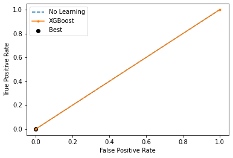

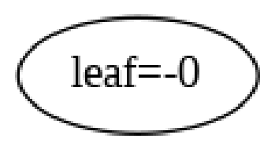

Este set de datos no tiene una referencia temporal aparente, ni un registro histórico de cada paciente, por lo que era de esperar que la prueba de serología que busca mostrar si alguien tuvo covid en el pasado no sea un target sencillo de predecir.

### Modelado #3 (PCR) Hábitos

Para seguir profundizando en la investigación de los datos, quisieramos predecir a partir de los hábitos, la probabilidad de que la prueba PCR salga positiva o negativa.

```
Split Listo
 La proporción entre clases es: 21.714285714285715
Best Threshold=0.538836, G-Mean=0.770
```

```
La matriz de confusión:
 [[127  26]
 [  3   4]]
Un ejemplo de árbol de decisión.
```

```
AUC Score:  0.7007469654528478
```

```
(None, <matplotlib.axes._subplots.AxesSubplot at 0x7fddb2c99450>)
```

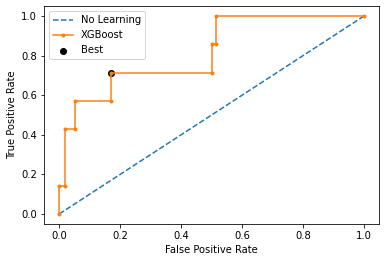

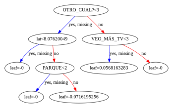

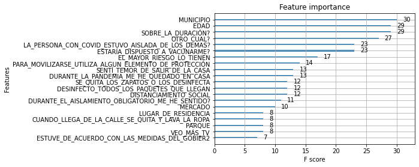

1. A partir de los hábitos de la persona es posible estimar si esta saldría positiva en la prueba o no.
2. Pueden existir 2 clusters de personas, los que se hicieron la prueba por precaución, sin tener sintomas, y los que ya padecían de éstos. Los síntomas están implícitos en los hábitos, por lo que el modelo está clasificando si la persona es del tipo de persona que contrae Covid, o no.

La primera afirmación es la más certera, pero para afirmar la segunda, necesitamos de un poco más de investigación.

### Modelado #4 (PCR) Síntomas

Modelando solo con los sintomas, queremos contrastar con qué podemos hacer mejores predicciones y obtener puntajes mayores. Por lo que en este apartado, excluimos el entorno de la persona y solo analizamos sus síntomas.

```
Split Listo
 La proporción entre clases es: 21.714285714285715
Best Threshold=0.556511, G-Mean=0.733
```

```
La matriz de confusión:
 [[135  18]
 [  4   3]]
Un ejemplo de árbol de decisión.
```

```
AUC Score:  0.6554621848739496
```

```
(None, <matplotlib.axes._subplots.AxesSubplot at 0x7fddb0e2ffd0>)
```

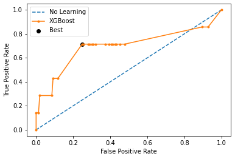

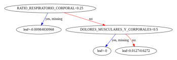

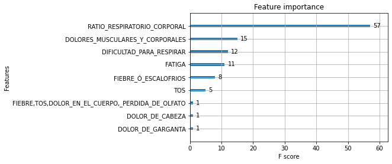

Analizando los sintomas sin considerar el contexto de la persona, no se obtienen tan buenos resultados como teniendo en cuenta el contexto aisladamente. Esto puede ser por personas asíntomaticas que contrajeron el virus debido a sus hábitos.

Los mejores resultados se obtienen combinando ambos tipos de variables.

### Analisís de Falsos Positivos y Falsos Negativos Modelo #1

El modelo 1 es el modelo que obtiene el mejor puntaje de AUC, es un modelo precavido (más Falsos Positivos que Falsos Negativos), y utiliza tanto el contexto de la persona (hábitos y forma de pensar) como los sintomas que presenta.

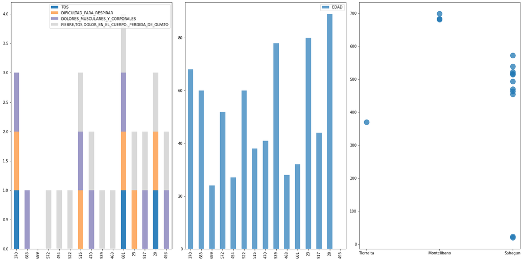

Teniendo en cuenta la convención:

Síntomas:

1. Sí.
2. No.

Municipios:

1. Lorica.
2. Planeta Rica.
3. Tierralta.
4. Sahagún.
5. Montelíbano.

Podemos ver que el Municipio que más falsos positivos genera es Sahagún, **No** tener *tos* o *dificultad para respirar*, **tener** *mareos y perdida del apetito*, tener *fiebre*, *dolores en el cuerpo o perdida del olfato*, y edad mayor a los 50 o 25 años.

Esto puede suceder como resultado de la importancia que da el modelo a la variable **Municipio** para predecir pacientes infectados por covid, si un paciente vive en Sahagún, en general el modelo lo clasificaría como alguien infectado obviando un poco sus síntomas respiratorios. Sin embargo, retomando el analisis de sintomatología por cada municipio, vemos que en Sahagún, los sintomas de Covid más frecuentes fueron Vomitos, perdida de apetito, y fiebre, dolor o perdida de olfato.

Por otra parte, esta precaución (bien hecha) puede ser de gran utilidad a la hora de decidir si hacerle la prueba o no a una determinada persona, de manera que podría servir de filtro inicial, o en caso que no haya disponibilidad de pruebas.

**Bonus Investigativo:** Internacionalmente y en diversos estudios de esta enfermedad, se ha comprobado que la prueba PCR es buena detectando casos positivos en pacientes que tengan sintomatología del sistema respiratorio, **pero** si el paciente presenta síntomas como vómitos, mareos, o coagulos en sangre, sin presentar síntomas respiratorios, es posible que la prueba salga negativa, a pesar de padecer la enfermedad.

El modelo fue entrenado buscando predecir los resultados de la PCR, pero estos "Falsos positivos" con sintomatología del sistema digestivo, pueden ser "Falsos Negativos" de la prueba PCR. Por lo que podemos pensar que el modelo es más viable que la prueba al momento de predecir si una persona tiene Covid o no, esta afirmación queda a disposición de futuras investigaciones, o despliegues reales.

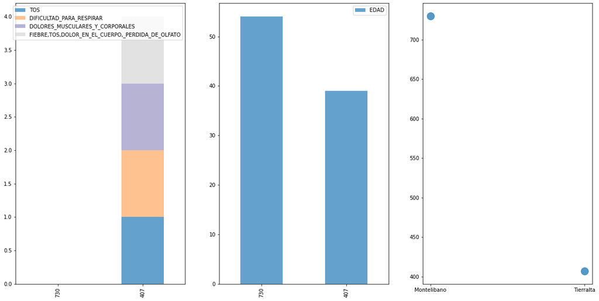

Esta es la situación que podría ser más preocupante de todas. Falso negativo sería una persona que **tiene** Covid, pero el modelo lo descartaría. En del paciente 730 no sería un gran problema al ser descartado, ya que no presenta sintomas de tos ni dificultad para respirar, que son los más críticos; es menos probable que empeore, contagie a otros, o siquiera sospeche de que tiene la enfermedad.

El paciente 407 sería algo peligroso. Este tiene alrededor de 40 años, es de Tierralta, presenta Tos y dificultad para respirar que son los sintomas más críticos, y aún así el modelo lo **descarta** como infectado por Covid. Podría desembocar en un agravamiento del paciente, así que lo ideal es que este tipo de casos no se presenten en el modelo.

### Análisis Verdaderos Negativos y Verdaderos Positivos Modelo #1

El análisis de los Falsos Negativos y Positivos arrojó algunas conclusiones, pero es necesario observar cuales son los pacientes que el modelo clasifica bien, y qué tienen en común.

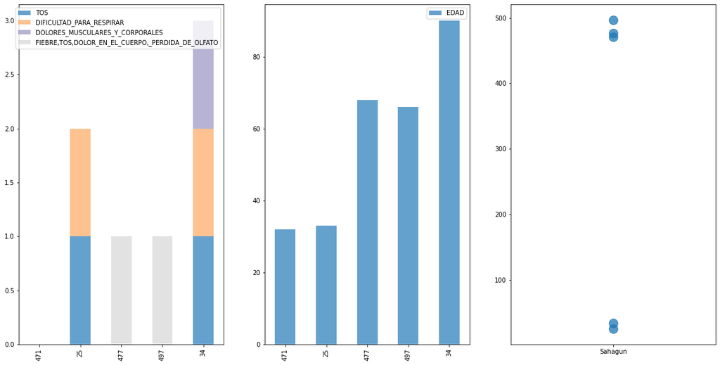

Estando todos en el mismo municipio (Sahagún) el modelo fue capaz de detectar casos positivos según la prueba PCR con sintomatologías distintas, el paciente 471 podría ser clasificado gracias a sus hábitos, y ser del tipo asintomático, sin embargo, se requiere un análisis más detallado para entender cómo fue realizada la clasificación del modelo.

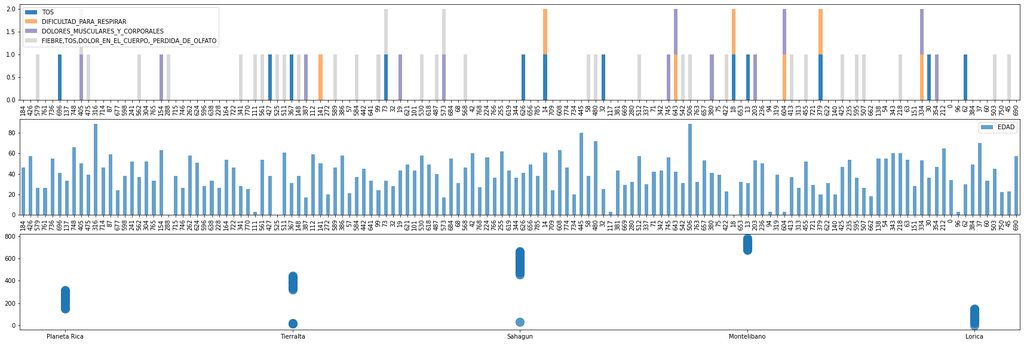

Podemos observar que la varios pacientes negativos en la prueba PCR tienen síntomas y están repartidos por los distintos mmunicipios, éstos pueden estar contagiados de alguna otra enfermedad, ó, ser **Falsos negativos** de la PCR.